# Regression

Kuanyu Lai

2024-03-28

## Regression

```r
library(tidymodels)
library(tidyverse)
library(doParallel)
registerDoParallel(makeCluster(4))
```

### Import Dataset

```r
dfii <- read_csv("dfii.csv", col_names = TRUE )
```

```
## ──────────────────────────────────────────────────────── Delimiter: "," chr
## (2): Lightness, Saturation dbl (7): ...1, R, G, B, Hue, y, outcome
```

```r
glimpse(dfii)
```

```
## Rows: 835
## Columns: 9
## $ ...1       <dbl> 1, 2, 3, 4, 5, 6, 7, 8, 9, 10, 11, 12, 13, 14, 15, 16, 17, …
## $ R          <dbl> 172, 26, 172, 28, 170, 175, 90, 194, 171, 122, 0, 88, 144, …
## $ G          <dbl> 58, 88, 94, 87, 66, 89, 78, 106, 68, 151, 121, 140, 82, 163…
## $ B          <dbl> 62, 151, 58, 152, 58, 65, 136, 53, 107, 59, 88, 58, 132, 50…
## $ Lightness  <chr> "dark", "dark", "dark", "dark", "dark", "dark", "dark", "da…
## $ Saturation <chr> "bright", "bright", "bright", "bright", "bright", "bright",…
## $ Hue        <dbl> 4, 31, 8, 32, 5, 6, 34, 10, 1, 21, 24, 22, 36, 16, 26, 12, …
## $ y          <dbl> -1.9924302, -2.1972246, -1.6582281, -2.1972246, -2.0907411,…
## $ outcome    <dbl> 1, 1, 1, 0, 0, 0, 0, 0, 0, 0, 0, 0, 0, 0, 0, 0, 0, 0, 1, 1,…
```

### Transform Response

```r
dfii <- dfii %>%
  mutate(
    Lightness = factor(Lightness, ordered = FALSE),
    Saturation = factor(Saturation, ordered = FALSE)) |>
    select(-outcome)

str(dfii)
```

```
## tibble [835 × 8] (S3: tbl_df/tbl/data.frame)
##  $ ...1      : num [1:835] 1 2 3 4 5 6 7 8 9 10 ...
##  $ R         : num [1:835] 172 26 172 28 170 175 90 194 171 122 ...
##  $ G         : num [1:835] 58 88 94 87 66 89 78 106 68 151 ...
##  $ B         : num [1:835] 62 151 58 152 58 65 136 53 107 59 ...
##  $ Lightness : Factor w/ 7 levels "dark","deep",..: 1 1 1 1 1 1 1 1 1 1 ...
##  $ Saturation: Factor w/ 7 levels "bright","gray",..: 1 1 1 1 1 1 1 1 1 1 ...
##  $ Hue       : num [1:835] 4 31 8 32 5 6 34 10 1 21 ...
##  $ y         : num [1:835] -1.99 -2.2 -1.66 -2.2 -2.09 ...
```

### Baseline models

```r
lm_intercept <- lm(y~1, data = dfii)

lm_cat <- lm(y ~ Saturation+Lightness, data = dfii)

lm_con <- lm(y~R+G+B+Hue, data = dfii)

lm_all <- lm(y~., data = dfii)

lm_inter1 <- lm(y ~ (Saturation+Lightness)^2+R+G+B+Hue, data = dfii)

lm_inter2 <- lm(y~ Saturation+Lightness+(Hue+R+G+B)^2, data = dfii)

lm_inter3 <- lm(y~ (Saturation+Lightness)*(R+G+B+Hue)+(R+G+B+Hue)^2, data = dfii)

lm_non_lin1 <- lm(y~ (G+I(G^2)):Lightness,data = dfii)

lm_non_lin2 <- lm(y~ R+I(R^2)+G+I(G^2)+B+I(B^2),data = dfii)

lm_non_lin_inter <- lm(y~ (R + I(R^2) + G + I(G^2)) * Lightness,data = dfii)
```

### Evaluation of baseline models

```r
model_list <- list(lm_intercept, lm_cat,lm_con,lm_all,lm_inter1,lm_inter2,lm_inter3,lm_non_lin1,lm_non_lin2,lm_non_lin_inter)
adj_r_squared <- numeric(length(model_list))
model_names <- character(length(model_list))

for (i in seq_along(model_list)) {
  summary_info <- summary(model_list[[i]])
  adj_r_squared[i] <- summary_info$adj.r.squared
  model_names[i] <- paste("Model", i)
}

results_df <- tibble(Model = model_names, `Adjusted R-squared` = adj_r_squared)


results_df |>
  arrange(desc(adj_r_squared))
```

```
## # A tibble: 10 × 2
##    Model    `Adjusted R-squared`
##    <chr>                   <dbl>
##  1 Model 7                 0.998
##  2 Model 6                 0.996
##  3 Model 10                0.995
##  4 Model 5                 0.994
##  5 Model 4                 0.994
##  6 Model 9                 0.994
##  7 Model 3                 0.988
##  8 Model 8                 0.979
##  9 Model 2                 0.883
## 10 Model 1                 0
```

```r
rmse_values <- numeric(length(model_list))
for (i in seq_along(model_list)) {
  predictions <- predict(model_list[[i]], newdata = dfii)
  rmse_values[i] <- sqrt(mean((predictions - dfii$y)^2))
}
results_df <- tibble(Model = paste("Model", 1:length(model_list)), RMSE = rmse_values)

results_df |>
  arrange(RMSE)
```

```
## # A tibble: 10 × 2
##    Model      RMSE
##    <chr>     <dbl>
##  1 Model 7  0.0533
##  2 Model 6  0.0779
##  3 Model 10 0.0788
##  4 Model 5  0.0851
##  5 Model 4  0.0875
##  6 Model 9  0.0941
##  7 Model 3  0.129
##  8 Model 8  0.170
##  9 Model 2  0.402
## 10 Model 1  1.18
```

```r
bic_values <- numeric(length(model_list))
for (i in seq_along(model_list)) {

  bic_values[i] <- BIC(model_list[[i]])
}
results_df <- tibble(Model = paste("Model", 1:length(model_list)), BIC = bic_values)

results_df |>
  arrange(BIC)
```

```
## # A tibble: 10 × 2
##    Model       BIC
##    <chr>     <dbl>
##  1 Model 7  -2043.
##  2 Model 6  -1732.
##  3 Model 10 -1631.
##  4 Model 4  -1572.
##  5 Model 9  -1523.
##  6 Model 5  -1381.
##  7 Model 3  -1009.
##  8 Model 8   -480.
##  9 Model 2    942.
## 10 Model 1   2665.
```

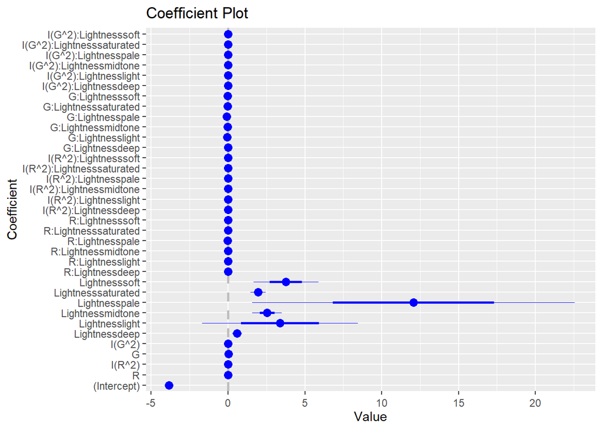

```r
coefplot::coefplot(lm_non_lin_inter)
```

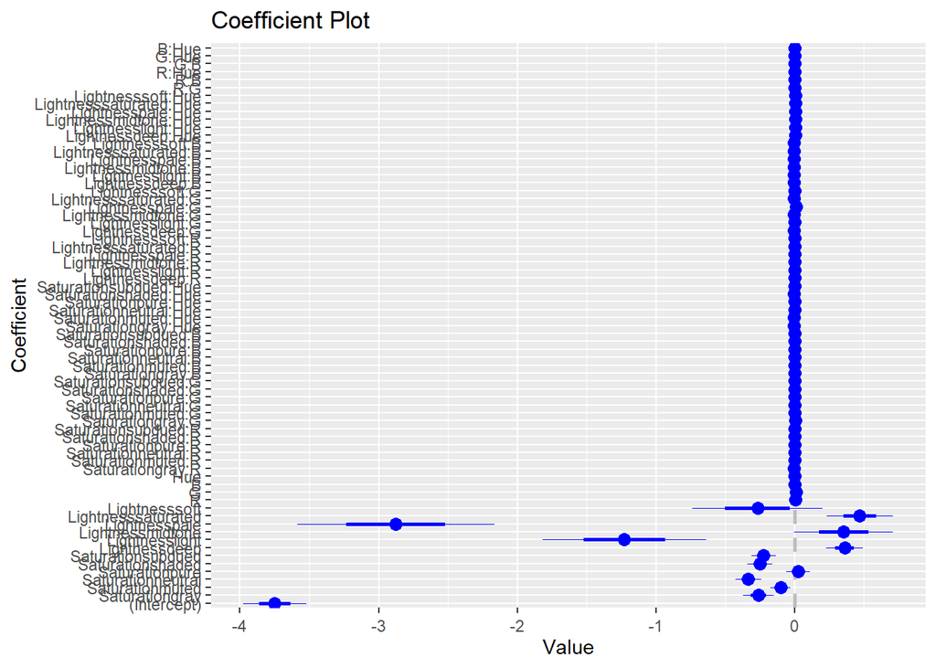

```r
coefplot::coefplot(lm_inter3)
```

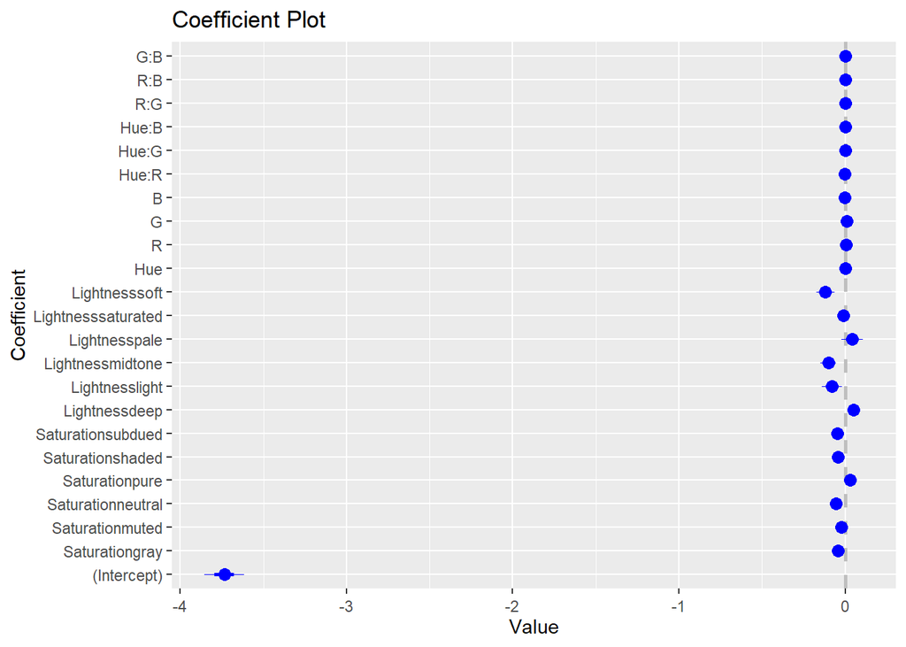

```r
coefplot::coefplot(lm_inter2)
```

From the output, the three continuous variable look very important, as well as lightness by looking at the interactions.

## Bayesian linear model

```r
lm_inter3_matrix <- model.matrix(formula(lm_inter3), data = dfii)
lm_inter2_matrix <- model.matrix(formula(lm_inter2), data = dfii)

info_inter3 <- list(
  yobs = dfii$y,
  design_matrix = lm_inter3_matrix,
  mu_beta = 0,
  tau_beta = 2,
  sigma_rate = 1
)

info_inter2 <- list(
  yobs = dfii$y,
  design_matrix = lm_inter2_matrix,
  mu_beta = 0,
  tau_beta = 2,
  sigma_rate = 1
)
```

```r
lm_logpost <- function(unknowns, my_info)
{
  # specify the number of unknown beta parameters
  length_beta <- ncol(my_info$design_matrix)
  # extract the beta parameters from the `unknowns` vector
  beta_v <- unknowns[1:length_beta]
  # extract the unbounded noise parameter, varphi
  lik_varphi <- unknowns[length_beta + 1]
  # back-transform from varphi to sigma
  lik_sigma <- exp(lik_varphi)
  # extract design matrix
  X <- my_info$design_matrix
  # calculate the linear predictor
  mu <- as.vector( X %*% as.matrix(beta_v) )
  # evaluate the log-likelihood
  log_lik <- sum(dnorm(x = my_info$yobs,
                       mean = mu,
                       sd = lik_sigma,
                       log = TRUE))
  # evaluate the log-prior
  log_prior_beta <- sum(dnorm(x = beta_v,
                              mean = my_info$mu_beta,
                              sd = my_info$tau_beta,
                              log = TRUE))

  log_prior_sigma <- dexp(x = lik_sigma,
                          rate = my_info$sigma_rate,
                          log = TRUE)

  # add the mean trend prior and noise prior together
  log_prior <- log_prior_beta + log_prior_sigma

  # account for the transformation
  log_derive_adjust <- lik_varphi

  # sum together
  log_lik + log_prior + log_derive_adjust
}
```

```r
my_laplace <- function(start_guess, logpost_func, ...)
{
  # code adapted from the `LearnBayes`` function `laplace()`
  fit <- optim(start_guess,
               logpost_func,
               gr = NULL,
               ...,
               method = "BFGS",
               hessian = TRUE,
               control = list(fnscale = -1, maxit = 1001))

  mode <- fit$par
  post_var_matrix <- -solve(fit$hessian)
  p <- length(mode)
  int <- p/2 * log(2 * pi) + 0.5 * log(det(post_var_matrix)) + logpost_func(mode, ...)
  # package all of the results into a list
  list(mode = mode,
       var_matrix = post_var_matrix,
       log_evidence = int,
       converge = ifelse(fit$convergence == 0,
                         "YES",
                         "NO"),
       iter_counts = as.numeric(fit$counts[1]))
}
```

```r
laplace_quad_inter3 <- my_laplace(rep(0, ncol(lm_inter3_matrix)+1), lm_logpost, info_inter3)
laplace_quad_inter2 <- my_laplace(rep(0, ncol(lm_inter2_matrix)+1), lm_logpost, info_inter2)
```

```r
generate_lm_post_samples <- function(mvn_result, length_beta, num_samples)
{
  MASS::mvrnorm(n = num_samples,
                mu = mvn_result$mode ,
                Sigma = mvn_result$var_matrix ) %>%
    as.data.frame() %>% tibble::as_tibble() %>%
    purrr::set_names(c(sprintf("beta_%02d", 0:(length_beta-1)), "varphi")) %>%
    mutate(sigma = exp(varphi))
}
```

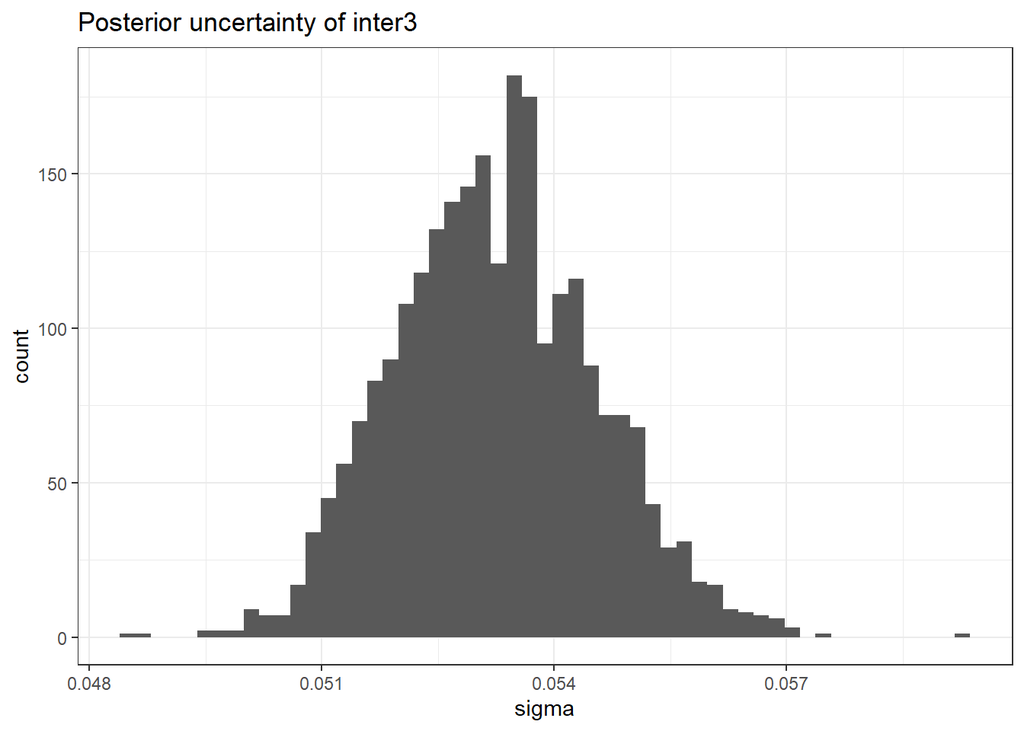

```r
set.seed(87123)

post_samples_inter3 <- generate_lm_post_samples(laplace_quad_inter3, ncol(lm_inter3_matrix), 2500)

post_samples_inter3 %>%
  ggplot(mapping = aes(x = sigma)) +
  labs(title = "Posterior uncertainty of inter3" )+
  geom_histogram(bins = 55) +
  theme_bw()
```

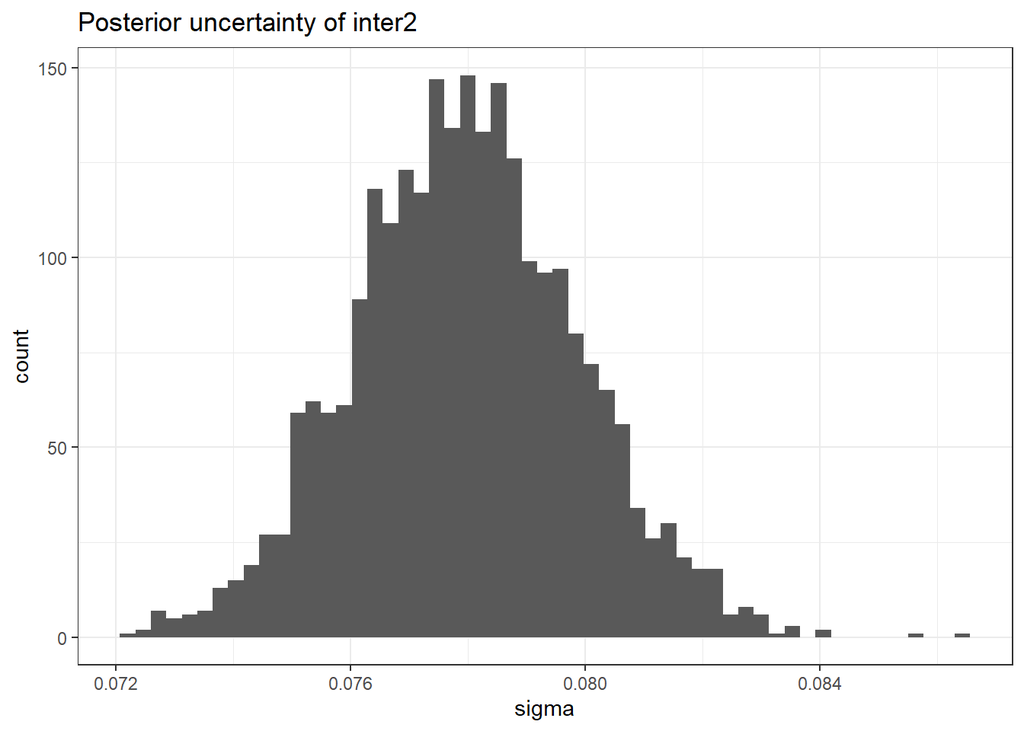

```r
post_samples_inter2 <- generate_lm_post_samples(laplace_quad_inter2, ncol(lm_inter2_matrix), 2500)

post_samples_inter2 %>%
  ggplot(mapping = aes(x = sigma)) +
  labs(title = "Posterior uncertainty of inter2" )+
  geom_histogram(bins = 55) +
  theme_bw()
```

```r
sigma(lm_inter3)
```

```
## [1] 0.05570054
```

```r
sigma(lm_inter2)
```

```
## [1] 0.07894837
```

```r
viz_post_coefs <- function(post_means, post_sds, xnames)
{
  tibble::tibble(
    mu = post_means,
    sd = post_sds,
    x = xnames
  ) %>%
    mutate(x = factor(x, levels = xnames)) %>%
    ggplot(mapping = aes(x = x)) +
    geom_hline(yintercept = 0, color = 'grey', linetype = 'dashed') +
    geom_point(mapping = aes(y = mu)) +
    geom_linerange(mapping = aes(ymin = mu - 2 * sd,
                                 ymax = mu + 2 * sd,
                                 group = x)) +
    labs(x = 'feature', y = 'coefficient value') +
    coord_flip() +
    theme_bw()
}
```

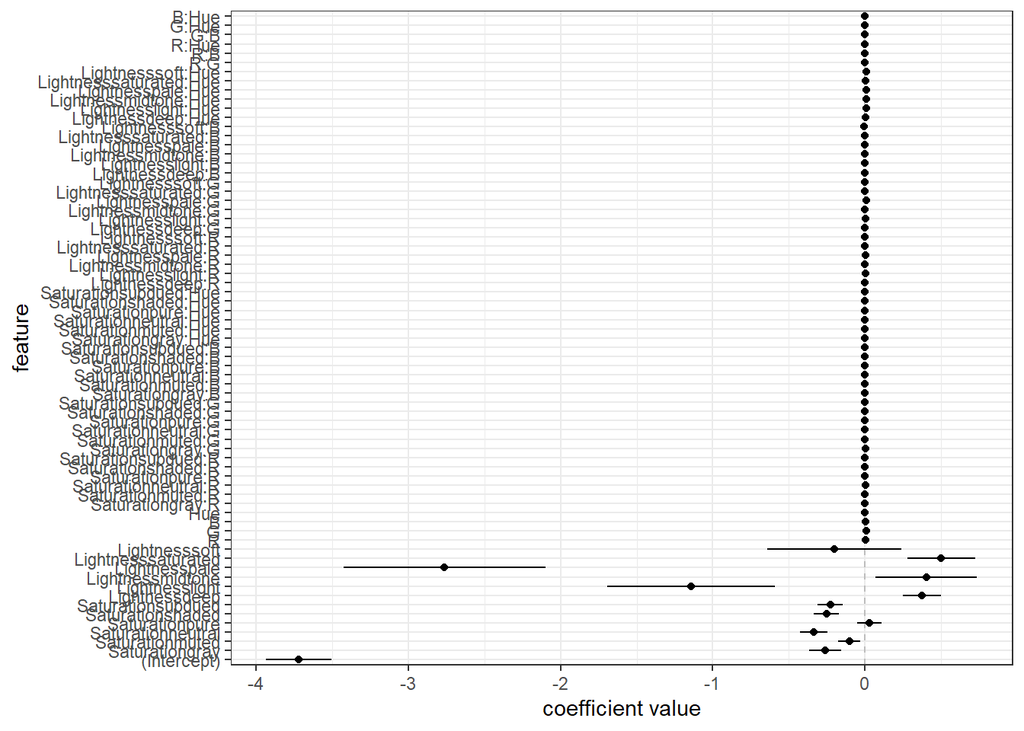

```r
viz_post_coefs(laplace_quad_inter3$mode[1:length(laplace_quad_inter3$mode)-1],
               sqrt(diag(laplace_quad_inter3$var_matrix[1:length(laplace_quad_inter3$mode)-1,1:length(laplace_quad_inter3$mode)-1])),
               colnames(lm_inter3_matrix))
```

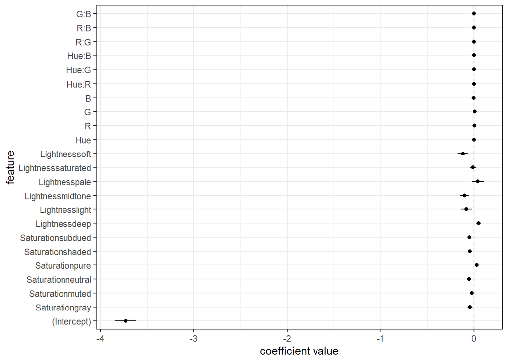

```r
viz_post_coefs(laplace_quad_inter2$mode[1:length(laplace_quad_inter2$mode)-1],
               sqrt(diag(laplace_quad_inter2$var_matrix[1:length(laplace_quad_inter2$mode)-1,1:length(laplace_quad_inter2$mode)-1])),
               colnames(lm_inter2_matrix))
```

```r
log_evidence_inter3 <- laplace_quad_inter3$log_evidence
log_evidence_inter2 <- laplace_quad_inter2$log_evidence

bayes_factor <- round(exp(log_evidence_inter3) / exp(log_evidence_inter2),5)

bayes_factor
```

```
## [1] 0
```

```r
reference_values <- tibble(
  G = median(dfii$G),
  B = median(dfii$B),
  Hue = median(dfii$Hue),
  Saturation = "neutral"
)

viz_grid <- expand.grid(R = seq(0, 255, length.out = 255 ),
                        G = reference_values$G,
                        B = reference_values$B,
                        Hue = reference_values$Hue,
                        Lightness = c("dark","deep","light","midtone","pale","saturated","soft"),
                        Saturation = factor(reference_values$Saturation, levels = levels(dfii$Saturation)),
                        KEEP.OUT.ATTRS = FALSE,
                        stringsAsFactors = FALSE
                    ) %>%
  as.data.frame() %>% tibble::as_tibble()
```

```r
generate_lm_post_samples <- function(mvn_result, length_beta, num_samples)
{
  MASS::mvrnorm(n = num_samples,
                mu = mvn_result$mode,
                Sigma = mvn_result$var_matrix) %>%
    as.data.frame() %>% tibble::as_tibble() %>%
    purrr::set_names(c(sprintf("beta_%02d", 0:(length_beta-1)), "varphi")) %>%
    mutate(sigma = exp(varphi))
}


post_lm_pred_samples <- function(Xnew, Bmat, sigma_vector)
{
  # number of new prediction locations
  M <- nrow(Xnew)
  # number of posterior samples
  S <- nrow(Bmat)

  # matrix of linear predictors
  Umat <- as.matrix(Xnew %*% t(Bmat))

  # assmeble matrix of sigma samples, set the number of rows
  Rmat <- matrix(rep(sigma_vector, M), nrow = M, byrow = TRUE)

  # generate standard normal and assemble into matrix
  # set the number of rows
  Zmat <- matrix(rnorm(M*S), nrow = M, byrow = TRUE)

  # calculate the random observation predictions
  Ymat <- Umat + Rmat * Zmat

  # package together
  list(Umat = Umat, Ymat = Ymat)
}

make_post_lm_pred <- function(Xnew, post)
{
  Bmat <- post %>% select(starts_with("beta_")) %>% as.matrix()

  sigma_vector <- post %>% pull(sigma)

  post_lm_pred_samples(Xnew, Bmat, sigma_vector)
}


summarize_lm_pred_from_laplace <- function(mvn_result, Xtest, num_samples)
{
  # generate posterior samples of the beta parameters
  post <- generate_lm_post_samples(mvn_result, ncol(Xtest), num_samples)

  # make posterior predictions on the test set
  pred_test <- make_post_lm_pred(Xtest, post)

  # calculate summary statistics on the predicted mean and response
  # summarize over the posterior samples

  # posterior mean, should you summarize along rows (rowMeans) or
  # summarize down columns (colMeans) ???
  mu_avg <- rowMeans(pred_test$Umat)
  y_avg <- rowMeans(pred_test$Ymat)

  # posterior quantiles for the middle 95% uncertainty intervals
  mu_lwr <- apply(pred_test$Umat, 1, stats::quantile, probs = 0.025)
  mu_upr <- apply(pred_test$Umat, 1, stats::quantile, probs = 0.975)
  y_lwr <- apply(pred_test$Ymat, 1, stats::quantile, probs = 0.025)
  y_upr <- apply(pred_test$Ymat, 1, stats::quantile, probs = 0.975)

  # book keeping
  tibble::tibble(
    mu_avg = mu_avg,
    mu_lwr = mu_lwr,
    mu_upr = mu_upr,
    y_avg = y_avg,
    y_lwr = y_lwr,
    y_upr = y_upr
  ) %>%
    tibble::rowid_to_column("pred_id")
}
```

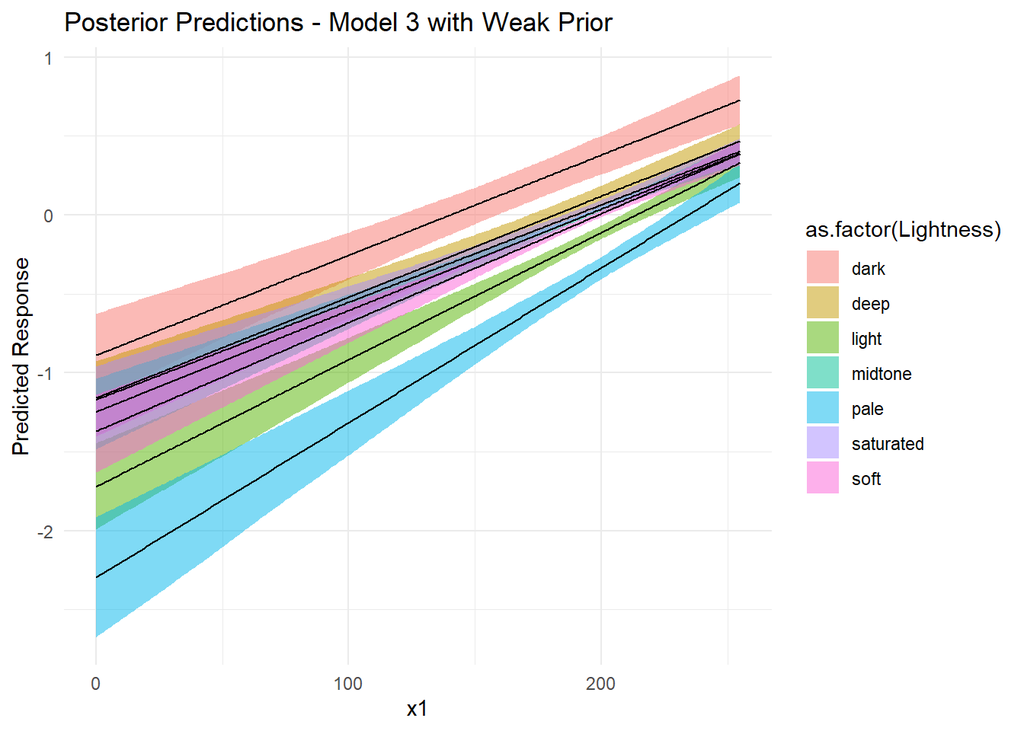

```r
inter3_test <- model.matrix(~ (Saturation + Lightness) * (R + G + B + Hue) + (R + G + B + Hue)^2, data = viz_grid)

post_pred_summary_viz_inter3 <- summarize_lm_pred_from_laplace(laplace_quad_inter3, inter3_test, num_samples = 1000)

post_pred_summary_viz_inter3 %>%
  left_join(viz_grid %>% tibble::rowid_to_column("pred_id"),
            by = 'pred_id') |>
  ggplot(aes(x = R, y = mu_avg, ymin = mu_lwr, ymax = mu_upr, fill = as.factor(Lightness))) +
  geom_ribbon(alpha = 0.5) +
  geom_line() +
  labs(title = "Posterior Predictions - Model 3 with Weak Prior",
       x = "x1",
       y = "Predicted Response") +
  theme_minimal()
```

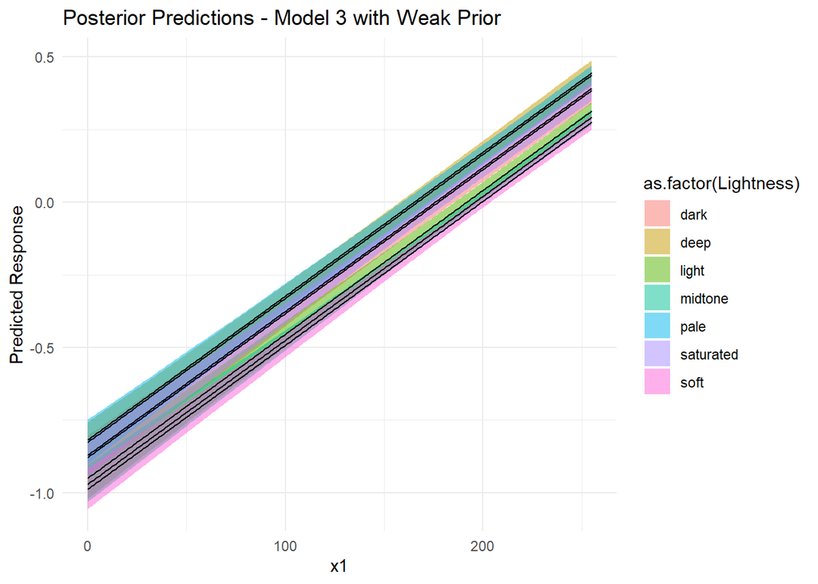

```r
inter2_test <- model.matrix(~ Saturation + Lightness + (Hue + R + G + B)^2, data = viz_grid)

post_pred_summary_viz_inter2 <- summarize_lm_pred_from_laplace(laplace_quad_inter2, inter2_test, num_samples = 1000)

post_pred_summary_viz_inter2 %>%
  left_join(viz_grid %>% tibble::rowid_to_column("pred_id"),
            by = 'pred_id') |>
  ggplot(aes(x = R, y = mu_avg, ymin = mu_lwr, ymax = mu_upr, fill = as.factor(Lightness))) +
  geom_ribbon(alpha = 0.5) +
  geom_line() +
  labs(title = "Posterior Predictions - Model 3 with Weak Prior",
       x = "x1",
       y = "Predicted Response") +
  theme_minimal()
```

## Complex models

### linear models

```r
lm_mod <-
  linear_reg() |> set_engine("lm")

#All categorical and continuous inputs - linear additive features
lm_fit <-
  lm_mod %>%
  fit(y ~ ., data = dfii)

#Add categorical inputs to all main effect and all pairwise interactions of continuous inputs
lm_fit_con_inter <-
  lm_mod %>%
  fit(y ~Saturation+Lightness+(R+B+G+Hue)^2, data = dfii)

#lm_inter3
lm_fit_inter3 <-
  lm_mod %>%
  fit(formula(lm_inter3), data = dfii)

lm_fit_nonlin <-
  lm_mod %>%
  fit(formula(lm_non_lin1), data = dfii)
```

```r
lm_fit_metrics <- lm_fit %>%
  predict(new_data = dfii) |>
  bind_cols(dfii) |>
  metrics(truth = y, estimate = .pred) |>
  select(.metric,.estimate)
lm_fit_con_inter_metrics <- lm_fit_con_inter %>%
  predict(new_data = dfii) %>%
  bind_cols(dfii) %>%
  metrics(truth = y, estimate = .pred) %>%
  select(.metric, .estimate)
lm_fit_inter3_metrics <- lm_fit_inter3 %>%
  predict(new_data = dfii) %>%
  bind_cols(dfii) %>%
  metrics(truth = y, estimate = .pred) %>%
  select(.metric, .estimate)
lm_fit_nonlin_metrics <- lm_fit_nonlin %>%
  predict(new_data = dfii) %>%
  bind_cols(dfii) %>%
  metrics(truth = y, estimate = .pred) %>%
  select(.metric, .estimate)
all_metrics <- bind_rows(
  lm_fit_metrics %>% mutate(model = "lm_fit"),
  lm_fit_con_inter_metrics %>% mutate(model = "lm_fit_con_inter"),
  lm_fit_inter3_metrics %>% mutate(model = "lm_fit_inter3"),
  lm_fit_nonlin_metrics %>% mutate(model = "lm_fit_nonlin")
)

metrics_table <- all_metrics %>%
  pivot_wider(names_from = .metric, values_from = .estimate)
metrics_table
```

```
## # A tibble: 4 × 4
##   model              rmse   rsq    mae
##   <chr>             <dbl> <dbl>  <dbl>
## 1 lm_fit           0.0875 0.995 0.0657
## 2 lm_fit_con_inter 0.0779 0.996 0.0589
## 3 lm_fit_inter3    0.0533 0.998 0.0395
## 4 lm_fit_nonlin    0.170  0.979 0.129
```

### Elastic nets

```r
#categorical inputs to all main effect and all pairwise interactions of continuous inputs
regularize_rec1 <-
  recipe(y ~ R+G+B+Hue+Saturation+Lightness,data = dfii) |>
  step_dummy(all_nominal_predictors()) |>
  step_interact(terms = ~ (R+G+B)^2) |>
  step_center(all_numeric_predictors())

elastic1_prep <- prep(regularize_rec1)

glmn_fit <-
  linear_reg(penalty = tune(), mixture  = 0.5) %>%
  set_engine("glmnet") |>
  set_mode("regression")

regularize1_wf <-
  workflow() |>
  add_recipe(regularize_rec1) |>
  add_model(glmn_fit)

#lm_inter3
regularize_rec2 <-
  recipe(y ~ R+G+B+Lightness+Saturation+ Hue,data = dfii) |>
  step_dummy(all_nominal_predictors()) |>
  step_interact(terms = ~ all_numeric_predictors():starts_with("Lightness_") +
                  all_numeric_predictors():starts_with("Saturation_")) |>
  step_interact(~(R+G+B+Hue):(R+G+B+Hue)) |>
  step_center(all_numeric_predictors())

elastic2_prep <- prep(regularize_rec2)

regularize2_wf <-
  workflow() |>
  add_recipe(regularize_rec2) |>
  add_model(glmn_fit)
```

### Tuning Elastic Nets

```r
set.seed(132)
tidy_kfold <- vfold_cv(dfii, v = 5, repeats = 5)

elastic_info <- extract_parameter_set_dials(glmn_fit)

#Create tune grid for models
elastic_grid <- grid_regular(elastic_info, levels = 15)

regularize_tune1 <- tune_grid(regularize1_wf,
                              resamples = tidy_kfold,
                              grid = elastic_grid)

regularize_tune2 <- tune_grid(regularize2_wf,
                              resamples = tidy_kfold,
                              grid = elastic_grid)
```

```r
(show_best(regularize_tune1))
```

```
## # A tibble: 5 × 7
##    penalty .metric .estimator   mean     n  std_err .config
##      <dbl> <chr>   <chr>       <dbl> <int>    <dbl> <chr>
## 1 1   e-10 rmse    standard   0.0836    25 0.000930 Preprocessor1_Model01
## 2 5.18e-10 rmse    standard   0.0836    25 0.000930 Preprocessor1_Model02
## 3 2.68e- 9 rmse    standard   0.0836    25 0.000930 Preprocessor1_Model03
## 4 1.39e- 8 rmse    standard   0.0836    25 0.000930 Preprocessor1_Model04
## 5 7.20e- 8 rmse    standard   0.0836    25 0.000930 Preprocessor1_Model05
```

```r
(show_best(regularize_tune2))
```

```
## # A tibble: 5 × 7
##    penalty .metric .estimator   mean     n  std_err .config
##      <dbl> <chr>   <chr>       <dbl> <int>    <dbl> <chr>
## 1 1   e-10 rmse    standard   0.0742    25 0.000804 Preprocessor1_Model01
## 2 5.18e-10 rmse    standard   0.0742    25 0.000804 Preprocessor1_Model02
## 3 2.68e- 9 rmse    standard   0.0742    25 0.000804 Preprocessor1_Model03
## 4 1.39e- 8 rmse    standard   0.0742    25 0.000804 Preprocessor1_Model04
## 5 7.20e- 8 rmse    standard   0.0742    25 0.000804 Preprocessor1_Model05
```

### Neural Network

```r
nn_recipe <-
  recipe(y ~R+G+B+Lightness+Saturation+ Hue,data = dfii) |>
  step_dummy(all_nominal_predictors()) |>
  step_normalize(all_numeric_predictors())


nn_spec <-
  mlp(epochs = tune(), hidden_units = tune(), penalty = tune(), activation = "tanh") |>
  set_engine("nnet", verbose = FALSE) |>
  set_mode("regression")

nn_workflow <-
  workflow() |>
  add_recipe(nn_recipe) |>
  add_model(nn_spec)
```

### Tuning NN

```r
set.seed(267)
nn_info <- extract_parameter_set_dials(nn_spec)

nn_grid <- grid_regular(nn_info, levels = 4)

nn_tune <- tune_grid(nn_workflow,
                     resamples = tidy_kfold,
                     grid = nn_grid)

show_best(nn_tune)[1,]
```

```
## # A tibble: 1 × 9
##   hidden_units  penalty epochs .metric .estimator   mean     n std_err .config
##          <int>    <dbl>  <int> <chr>   <chr>       <dbl> <int>   <dbl> <chr>
## 1            7 0.000464    670 rmse    standard   0.0480    25 0.00138 Preproce…
```

### Save best model

```r
final_nn <- nn_workflow |>
  finalize_workflow(select_best(nn_tune, metric= "rmse")) |>
  fit(dfii)

class(final_nn)
```

```
## [1] "workflow"
```

### Random forest

```r
rf_rec <-
  recipe(y~R+G+B+Lightness+Saturation+ Hue, data = dfii)

rf_fit <- rand_forest(mtry = tune(), trees = 1000, min_n = tune()) |>
  set_mode("regression") |>
  set_engine("ranger")

rf_wf <-
  workflow() |>
  add_recipe(rf_rec) |>
  add_model(rf_fit)
```

### Tune rf

```r
set.seed(976)

rf_info <- extract_parameter_set_dials(rf_fit) |> finalize(dfii)

ranger_tune <-
  tune_grid(rf_wf,
            resamples =tidy_kfold,
            param_info = rf_info,
            grid = 10)
```

```
## → A | warning: 7 columns were requested but there were 6 predictors in the data. 6 will be used.
```

[output not shown]

```r
show_best(ranger_tune, metric = "rmse")[1,]
```

```
## # A tibble: 1 × 8
##    mtry min_n .metric .estimator   mean     n std_err .config
##   <int> <int> <chr>   <chr>       <dbl> <int>   <dbl> <chr>
## 1     3    10 rmse    standard   0.0689     1      NA Preprocessor1_Model02
```

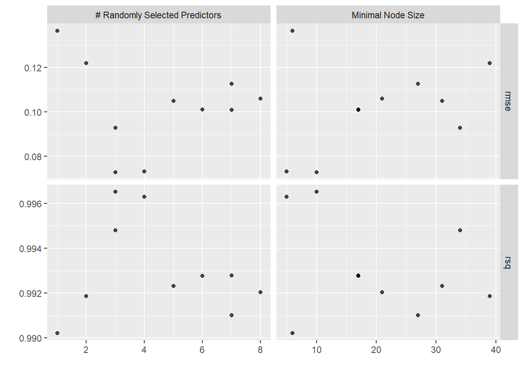

```r
autoplot(ranger_tune)
```

```r
final_rf <- rf_wf |>
  finalize_workflow(select_best(ranger_tune, metric= "rmse")) |>
  fit(dfii)

class(final_rf)
```

```
## [1] "workflow"
```

### Gradient Boosted Tree

```r
xgboost_recipe <-
  recipe(formula = y ~ R + G + B + Lightness + Saturation + Hue, data = dfii) %>%
  step_dummy(all_nominal_predictors()) |>
  step_zv(all_predictors())

xgboost_spec <-
  boost_tree(learn_rate = tune(),loss_reduction = tune(), trees = 500) %>%
  set_mode("regression") %>%
  set_engine("xgboost")

xgboost_workflow <-
  workflow() %>%
  add_recipe(xgboost_recipe) %>%
  add_model(xgboost_spec)
```

### tune Boosted Tree

```r
set.seed(154)

xgb_grid <- grid_regular(parameters(xgboost_spec), levels = 5)

xgb_tune <-
  tune_grid(xgboost_workflow,
            resamples =tidy_kfold,
            grid = xgb_grid)

show_best(xgb_tune)
```

```
## # A tibble: 5 × 8
##   learn_rate loss_reduction .metric .estimator   mean     n std_err .config
##        <dbl>          <dbl> <chr>   <chr>       <dbl> <int>   <dbl> <chr>
## 1     0.0750   0.0000000001 rmse    standard   0.0711    25 0.00128 Preprocesso…
## 2     0.0750   0.0000000750 rmse    standard   0.0711    25 0.00128 Preprocesso…
## 3     0.0750   0.0000562    rmse    standard   0.0712    25 0.00129 Preprocesso…
## 4     0.0178   0.0000562    rmse    standard   0.0721    25 0.00145 Preprocesso…
## 5     0.0178   0.0000000001 rmse    standard   0.0722    25 0.00145 Preprocesso…
```

### SVM

```r
kernlab_recipe <-
  recipe(formula = y ~ R + G + B + Lightness + Saturation + Hue, data = dfii) %>%
  step_dummy(all_nominal_predictors()) |>
  step_zv(all_predictors()) %>%
  step_normalize(all_numeric_predictors())

kernlab_spec <-
  svm_poly(cost = tune(), degree = tune(), scale_factor = tune()) %>%
  set_mode("regression")


kernlab_workflow <-
  workflow() %>%
  add_recipe(kernlab_recipe) %>%
  add_model(kernlab_spec)
```

### Tune svm

```r
model_metric <- metric_set(rmse)
svm_grid <- grid_regular(parameters(kernlab_spec), levels = 5)

set.seed(54900)
kernlab_tune <-
  tune_grid(kernlab_workflow, resamples =tidy_kfold , grid = svm_grid, metrics = model_metric)
```

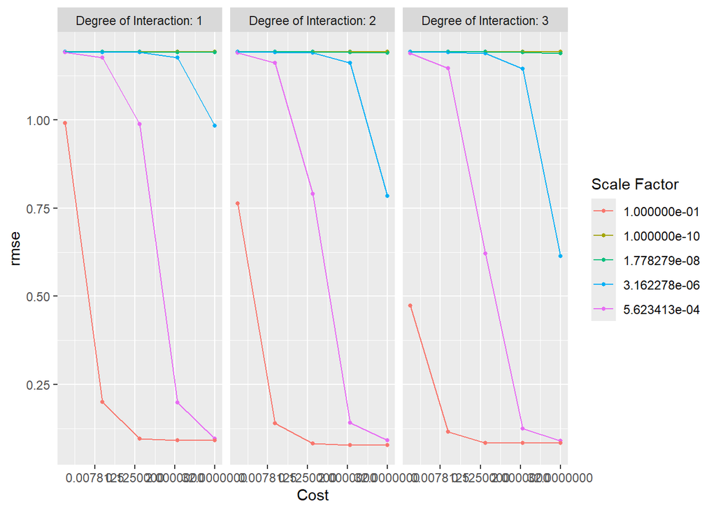

```r
autoplot(kernlab_tune)
```

```r
show_best(kernlab_tune, metric = "rmse")[1,]
```

```
## # A tibble: 1 × 9
##    cost degree scale_factor .metric .estimator   mean     n  std_err .config
##   <dbl>  <int>        <dbl> <chr>   <chr>       <dbl> <int>    <dbl> <chr>
## 1  2.38      2          0.1 rmse    standard   0.0771    25 0.000815 Preprocess…
```

```r
final_svm <- kernlab_workflow |>
  finalize_workflow(select_best(kernlab_tune, metric= "rmse")) |>
  fit(dfii)
```

### KNN

```r
kknn_recipe <-
  recipe(formula = y ~ R + G + B + Lightness + Saturation + Hue, data = dfii) %>%
  step_zv(all_predictors()) %>%
  step_normalize(all_numeric_predictors()) |>
  step_dummy(all_nominal_predictors())


kknn_spec <-
  nearest_neighbor(neighbors = tune(), weight_func = tune()) %>%
  set_mode("regression") %>%
  set_engine("kknn")

kknn_workflow <-
  workflow() %>%
  add_recipe(kknn_recipe) %>%
  add_model(kknn_spec)
```

### Tune KNN

```r
knn_info <- extract_parameter_set_dials(kknn_spec)

knn_grid <- grid_regular(knn_info, levels = 5)

set.seed(89162)
kknn_tune <-
  tune_grid(kknn_workflow, resamples = tidy_kfold, grid = knn_grid)
```

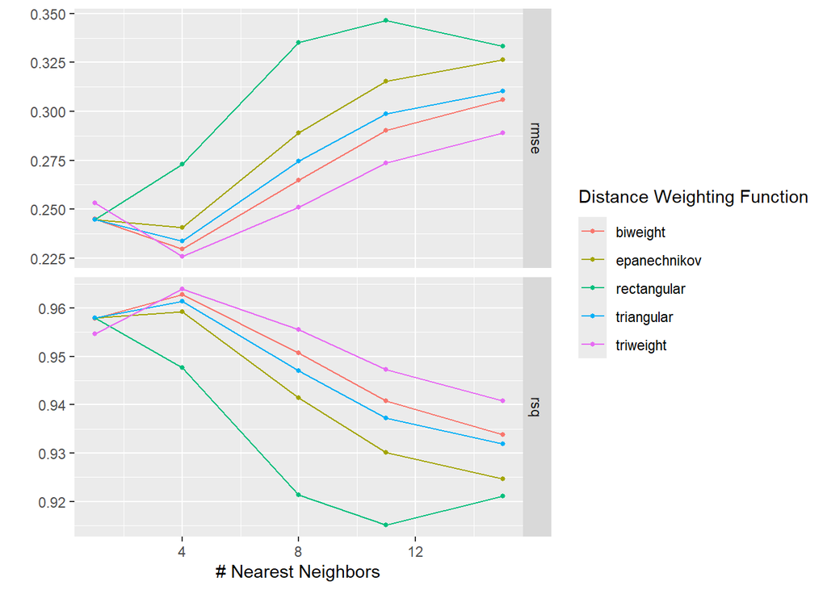

```r
autoplot(kknn_tune)
```

```r
show_best(kknn_tune)
```

```
## # A tibble: 5 × 8
##   neighbors weight_func  .metric .estimator  mean     n std_err .config
##       <int> <chr>        <chr>   <chr>      <dbl> <int>   <dbl> <chr>
## 1         4 triweight    rmse    standard   0.226    25 0.00219 Preprocessor1_M…
## 2         4 biweight     rmse    standard   0.230    25 0.00221 Preprocessor1_M…
## 3         4 triangular   rmse    standard   0.234    25 0.00237 Preprocessor1_M…
## 4         4 epanechnikov rmse    standard   0.241    25 0.00244 Preprocessor1_M…
## 5         1 rectangular  rmse    standard   0.245    25 0.00253 Preprocessor1_M…
```

```r
final_knn <- kknn_workflow |>
  finalize_workflow(select_best(kknn_tune, metric= "rmse"))
```

### save the best model for prediction

From the cross validation, the neural network has the ebst results among all the other models, so we will use neural network as our prediction model.

```r
library(bundle)

final_nn <- bundle(final_nn)

final_nn |> readr::write_rds("nn_reg.rds")

final_nn <- unbundle(final_nn)
```

## Variable Importance

### Local Explanation

```r
library(DALEXtra)
vip_features <- c("R", "G", "B",
                  "Hue", "Saturation", "Lightness")


explainer_nn <-
  explain_tidymodels(
    final_nn,
    data = dfii,
    y = dfii$y,
    label = "neural network",
    verbose = FALSE
  )
```

```r
duplex <- dfii[120,]
duplex
```

```
## # A tibble: 1 × 8
##    ...1     R     G     B Lightness Saturation   Hue      y
##   <dbl> <dbl> <dbl> <dbl> <fct>     <fct>      <dbl>  <dbl>
## 1   120   216   129   103 deep      bright         7 -0.847
```

```r
nn_breakdown <- predict_parts(explainer = explainer_nn, new_observation = duplex)
nn_breakdown
```

```
##                                        contribution
## neural network: intercept                    -0.109
## neural network: G = 129                      -0.843
## neural network: Lightness = deep              0.049
## neural network: B = 103                      -0.103
## neural network: R = 216                       0.165
## neural network: Saturation = bright           0.001
## neural network: Hue = 7                      -0.022
## neural network: ...1 = 120                    0.000
## neural network: y = -0.847297860387204        0.000
## neural network: prediction                   -0.863
```

```r
predict_parts(
  explainer = explainer_nn,
  new_observation = duplex,
  order = nn_breakdown$variable_name
)
```

```
##                                        contribution
## neural network: intercept                    -0.109
## neural network: G = 129                      -0.843
## neural network: Lightness = deep              0.049
## neural network: B = 103                      -0.103
## neural network: R = 216                       0.165
## neural network: Saturation = bright           0.001
## neural network: Hue = 7                      -0.022
## neural network: ...1 = 120                    0.000
## neural network: y = -0.847297860387204        0.000
## neural network: prediction                   -0.863
```

```r
set.seed(1801)

shap_duplex <-
  predict_parts(
    explainer = explainer_nn,
    new_observation = duplex,
    type = "shap",
    B = 20
  )
```

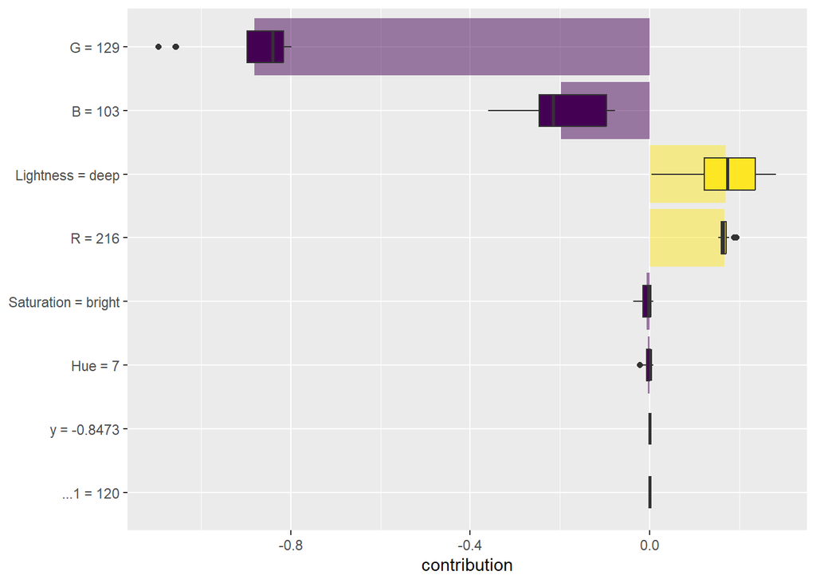

```r
library(forcats)
shap_duplex %>%
  group_by(variable) %>%
  mutate(mean_val = mean(contribution)) %>%
  ungroup() %>%
  mutate(variable = fct_reorder(variable, abs(mean_val))) %>%
  ggplot(aes(contribution, variable, fill = mean_val > 0)) +
  geom_col(data = ~distinct(., variable, mean_val),
           aes(mean_val, variable),
           alpha = 0.5) +
  geom_boxplot(width = 0.5) +
  theme(legend.position = "none") +
  scale_fill_viridis_d() +
  labs(y = NULL)
```

### Global Explanation

```r
set.seed(1804)
vip_nn <- model_parts(explainer_nn, loss_function = loss_root_mean_square)
```

```r
ggplot_imp <- function(...) {
  obj <- list(...)
  metric_name <- attr(obj[[1]], "loss_name")
  metric_lab <- paste(metric_name,
                      "after permutations\n(higher indicates more important)")

  full_vip <- bind_rows(obj) %>%
    filter(variable != "_baseline_")

  perm_vals <- full_vip %>%
    filter(variable == "_full_model_") %>%
    group_by(label) %>%
    summarise(dropout_loss = mean(dropout_loss))

  p <- full_vip %>%
    filter(variable != "_full_model_") %>%
    mutate(variable = fct_reorder(variable, dropout_loss)) %>%
    ggplot(aes(dropout_loss, variable))
  if(length(obj) > 1) {
    p <- p +
      facet_wrap(vars(label)) +
      geom_vline(data = perm_vals, aes(xintercept = dropout_loss, color = label),
                 linewidth = 1.4, lty = 2, alpha = 0.7) +
      geom_boxplot(aes(color = label, fill = label), alpha = 0.2)
  } else {
    p <- p +
      geom_vline(data = perm_vals, aes(xintercept = dropout_loss),
                 linewidth = 1.4, lty = 2, alpha = 0.7) +
      geom_boxplot(fill = "#91CBD765", alpha = 0.4)

  }
  p +
    theme(legend.position = "none") +
    labs(x = metric_lab,
         y = NULL,  fill = NULL,  color = NULL)
}
```

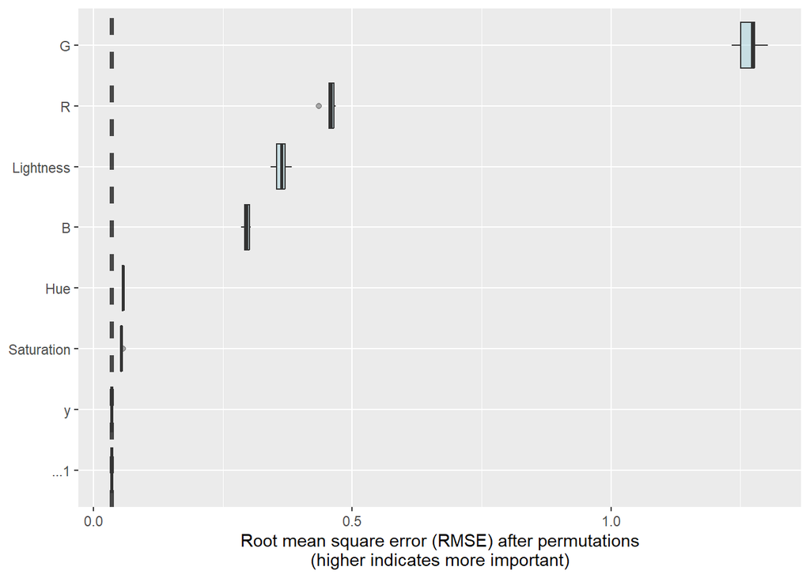

```r
ggplot_imp(vip_nn)
```

For variable importance, I choose to use SHAP value to evaluate how each variable contribute to the model, SHAP value is used in machine learning to explain individual predictions. Originating from game theory, SHAP values measure the contribution of each feature to a prediction relative to an average baseline. This is done by considering all possible combinations of features and calculating the change in the prediction when a feature is added. The result is a fair distribution of the prediction’s attribution among all the features. Based on the plot, the color paints really help predict the popular paints.

## Input insights

### Hardest and easiest to predict

```r
predictions <- predict(final_nn, new_data = dfii) %>%
  bind_cols(dfii) %>%
  mutate(error = abs(y - .pred))
average_error_by_group <- predictions %>%
  group_by(Lightness, Saturation) %>%
  summarise(AverageError = mean(error))
easiest_reg <- average_error_by_group[which.min(average_error_by_group$AverageError),]
hardest_reg <- average_error_by_group[which.max(average_error_by_group$AverageError),]

easiest_reg
```

```
## # A tibble: 1 × 3
## # Groups:   Lightness [1]
##   Lightness Saturation AverageError
##   <fct>     <fct>             <dbl>
## 1 light     gray             0.0130
```

```r
hardest_reg
```

```
## # A tibble: 1 × 3
## # Groups:   Lightness [1]
##   Lightness Saturation AverageError
##   <fct>     <fct>             <dbl>
## 1 dark      shaded           0.0531
```

### Prediction

```r
values <- expand.grid(R = seq(min(dfii$R), max(dfii$R), length.out = 101),
                      G = seq(min(dfii$G), max(dfii$G), length.out = 101))
values$B <- median(dfii$B)
values$Hue <- median(dfii$Hue)
values$Saturation <- "gray"
values$Lightness <- "light"
```

```r
reg_predictions_easy <- predict(final_nn, new_data = values)
```

### Surface plot

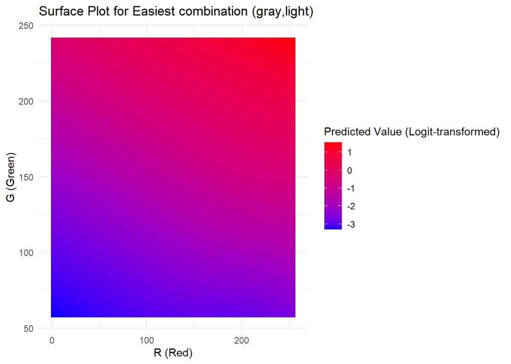

```r
values$Prediction <- reg_predictions_easy$.pred

ggplot(values, aes(x = R, y = G, fill = Prediction)) +
  geom_raster() +
  scale_fill_gradient(low = "blue", high = "red") +
  labs(x = "R (Red)", y = "G (Green)", fill = "Predicted Value (Logit-transformed)") +
  ggtitle("Surface Plot for Easiest combination (gray,light)") +
  theme_minimal()
```

```r
values$Saturation <- "shaded"
values$Lightness <- "dark"
```

```r
reg_predictions_hard <- predict(final_nn, new_data = values)
```

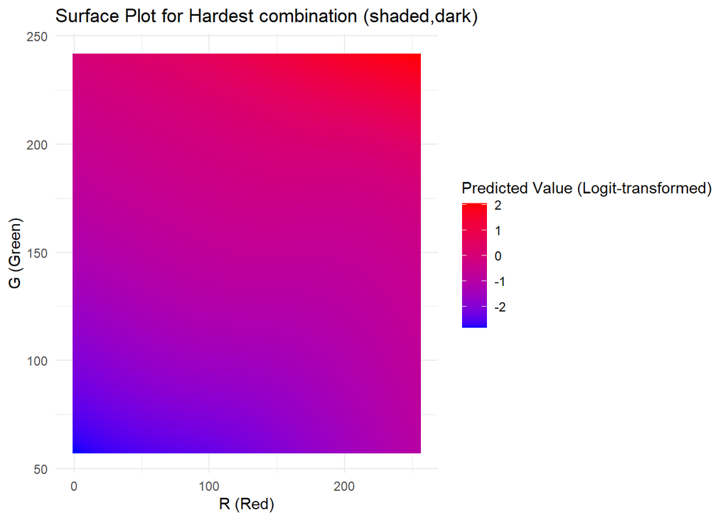

```r
values$Prediction <- reg_predictions_hard$.pred

ggplot(values, aes(x = R, y = G, fill = Prediction)) +
  geom_raster() +
  scale_fill_gradient(low = "blue", high = "red") +
  labs(x = "R (Red)", y = "G (Green)", fill = "Predicted Value (Logit-transformed)") +
  ggtitle("Surface Plot for Hardest combination (shaded,dark)") +
  theme_minimal()
```

From the plot they look pretty similar